# Implementación I - Algoritmo KNN.

## Lectura y limpieza de los datos.

Leo el dataset e imprimo 10 muestras aleatorias.

```python
import pandas as pd

df = pd.read_csv("data/star_class_clean.csv")
df.sample(10)
```

|  | alpha | delta | u | g | r | i | z | field_ID | spec_obj_ID | redshift | plate | MJD | fiber_ID | class |
| --- | --- | --- | --- | --- | --- | --- | --- | --- | --- | --- | --- | --- | --- | --- |
| 79486 | 204.201330 | 39.709858 | 22.11395 | 21.77280 | 21.44338 | 21.09295 | 21.16099 | 25 | 9.959900e+18 | 1.433050 | 8846 | 57428 | 688 | QSO |
| 76420 | 241.121928 | 25.471471 | 22.30181 | 21.69720 | 21.61575 | 21.55660 | 20.72822 | 216 | 4.429479e+18 | 2.481148 | 3934 | 55336 | 686 | QSO |
| 64908 | 132.771685 | 35.459204 | 24.34941 | 23.11455 | 21.48581 | 20.37616 | 19.70360 | 54 | 1.152828e+19 | 0.632131 | 10239 | 58142 | 693 | GALAXY |
| 75534 | 195.860178 | 18.506971 | 23.62883 | 22.73316 | 20.87518 | 19.96976 | 19.40876 | 124 | 6.601297e+18 | 0.524735 | 5863 | 56042 | 529 | GALAXY |
| 15296 | 254.783666 | 31.476829 | 21.41440 | 20.95016 | 21.04357 | 21.45027 | 21.67579 | 306 | 1.227352e+19 | 0.000316 | 10901 | 58397 | 322 | STAR |
| 72979 | 14.624270 | 3.665735 | 22.82695 | 22.19277 | 21.89945 | 20.92310 | 21.89311 | 427 | 1.061847e+19 | 1.001966 | 9431 | 58102 | 389 | GALAXY |
| 74091 | 251.905520 | 40.492937 | 23.78125 | 21.97086 | 20.56124 | 19.55478 | 18.97908 | 34 | 6.797136e+18 | 0.610543 | 6037 | 56104 | 283 | GALAXY |
| 31503 | 246.886387 | 42.023716 | 19.60826 | 19.43139 | 19.42399 | 19.20606 | 19.15402 | 329 | 9.597356e+18 | 1.669271 | 8524 | 57656 | 675 | QSO |
| 35104 | 220.116909 | 28.720763 | 23.11416 | 22.06873 | 20.26257 | 19.37329 | 18.88811 | 84 | 6.781502e+18 | 0.452568 | 6023 | 56069 | 753 | GALAXY |
| 47473 | 140.240890 | 16.382553 | 23.47075 | 22.52116 | 22.07397 | 21.36573 | 20.89046 | 65 | 1.075023e+19 | 0.844560 | 9548 | 57785 | 489 | GALAXY |

Cambio de estructura de datos a numpy y transformación de las etiquetas a números.

- Obtengo las variables de entrada (X) y de salida (y).
- Posteriormente instancio un objeto de la clase LabelEncoder() y transformo las etiquetas (clases) a números.
- Por último, estandarizo las características de los datos.

```python
from sklearn import preprocessing
from sklearn.preprocessing import StandardScaler

# Selecciono las variables de entrada y la variable de salida
x_vars = df.columns[:-1]
X = df[x_vars].values
y_labels = df['class'].values

# Instancia y aplica LabelEncoder a las etiquetas
le = preprocessing.LabelEncoder()
y = le.fit_transform(y_labels)

# Aplica StandardScaler a las características
scaler = StandardScaler()
X = scaler.fit_transform(X)

df.sample(10)
```

|  | alpha | delta | u | g | r | i | z | field_ID | spec_obj_ID | redshift | plate | MJD | fiber_ID | class |
| --- | --- | --- | --- | --- | --- | --- | --- | --- | --- | --- | --- | --- | --- | --- |
| 13279 | 183.023102 | 28.772525 | 20.89593 | 18.76751 | 17.33133 | 16.79834 | 16.48854 | 438 | 2.508518e+18 | 0.236620 | 2228 | 53818 | 48 | GALAXY |
| 15176 | 219.564375 | 41.227933 | 23.21844 | 21.98563 | 19.99921 | 18.76547 | 18.16996 | 190 | 6.824183e+18 | 0.682366 | 6061 | 56076 | 375 | GALAXY |
| 53664 | 242.314688 | 33.003660 | 24.53789 | 23.61334 | 21.84957 | 20.77617 | 19.88113 | 85 | 1.228599e+19 | 0.633325 | 10912 | 58253 | 611 | GALAXY |
| 65698 | 354.725809 | 16.703670 | 21.19001 | 19.08604 | 17.76081 | 17.20839 | 16.80304 | 197 | 6.909920e+18 | 0.184802 | 6137 | 56270 | 990 | GALAXY |
| 33962 | 150.907014 | 45.978878 | 22.29498 | 21.55546 | 21.55012 | 21.49448 | 21.39379 | 169 | 5.284010e+18 | 2.483414 | 4693 | 55632 | 588 | QSO |
| 91741 | 221.055280 | 6.062818 | 23.09246 | 21.17985 | 20.03066 | 19.20265 | 18.58279 | 72 | 5.469728e+18 | -0.000126 | 4858 | 55686 | 387 | STAR |
| 7554 | 231.806306 | 28.617303 | 22.31282 | 19.34905 | 18.38629 | 17.50096 | 16.95956 | 213 | 5.315422e+18 | 0.000033 | 4721 | 55709 | 177 | STAR |
| 19222 | 128.211336 | 34.764071 | 21.00376 | 20.66948 | 20.61486 | 20.46541 | 20.33070 | 32 | 1.311789e+19 | 0.728829 | 11651 | 58511 | 112 | QSO |
| 79600 | 196.674520 | -0.243813 | 19.69598 | 18.78277 | 18.42058 | 18.30522 | 18.25097 | 355 | 8.394846e+18 | 0.000313 | 7456 | 56727 | 496 | STAR |
| 55540 | 358.120985 | 11.790722 | 25.03729 | 21.47393 | 21.29969 | 20.95480 | 20.38878 | 298 | 6.934643e+18 | 2.718362 | 6159 | 56214 | 821 | QSO |

Observo que las clases estén codificadas:

```python
# Imprimo las clases y las etiquetas numéricas asociadas
for i, class_label in enumerate(le.classes_):
    print(f'Clase "{class_label}" está codificada como {i}')
```

```
Clase "GALAXY" está codificada como 0
Clase "QSO" está codificada como 1
Clase "STAR" está codificada como 2
```

Como las variables 2 (u), 3(g) y 6(z) contienen outliers, procedo a eliminarlos para mejorar la precisión del modelo:

```python
import numpy as np

# Calculamos el IQR para cada columna
Q1 = np.percentile(X, 25, axis=0)
Q3 = np.percentile(X, 75, axis=0)
IQR = Q3 - Q1

# Definimos los límites de los outliers
lower_bound = Q1 - 1.5 * IQR
upper_bound = Q3 + 1.5 * IQR

# Definimos una máscara que indica dónde están los outliers para cada columna
outliers = (X < lower_bound) | (X > upper_bound)

# Eliminamos los outliers
X = X[~np.any(outliers, axis=1)]
y = y[~np.any(outliers, axis=1)]

print("Outliers eliminados correctamente")
```

```
Outliers eliminados correctamente
```

## Creación y ajuste de los modelos.

Primero dividimos los datos en entrenamiento (80%) y test (20%).

```python
from sklearn.model_selection import train_test_split

X_train, X_test, y_train, y_test = train_test_split(X, y, test_size=0.2, random_state=0)

print("Dataset dividido en train y test.")
```

```
Dataset dividido en train y test.
```

Posteriormente, creamos varios modelos KNN utilizando diferente número de vecinos para los siguientes K:

```python
from sklearn.neighbors import KNeighborsClassifier
import time

modelos = {'Knn K=1': KNeighborsClassifier(n_neighbors=1),
           'Knn K=2': KNeighborsClassifier(n_neighbors=2),
           'Knn K=3': KNeighborsClassifier(n_neighbors=3),
           'Knn K=5': KNeighborsClassifier(n_neighbors=5),
           'Knn K=10': KNeighborsClassifier(n_neighbors=10),
           'Knn K=20': KNeighborsClassifier(n_neighbors=20),
           'Knn K=50': KNeighborsClassifier(n_neighbors=50),
           'Knn K=100': KNeighborsClassifier(n_neighbors=100),
           'Knn K=150': KNeighborsClassifier(n_neighbors=150)}

# Ajuste de los modelos y cálculo del tiempo de entrenamiento
tiempos_entrenamiento = {}
for k, v in modelos.items():
    print('Creando y entrenando modelo:', k)
    inicio = time.time()
    v.fit(X_train, y_train)
    fin = time.time()
    tiempos_entrenamiento[k] = fin - inicio
```

```
Creando y entrenando modelo: Knn K=1
Creando y entrenando modelo: Knn K=2
Creando y entrenando modelo: Knn K=3
Creando y entrenando modelo: Knn K=5
Creando y entrenando modelo: Knn K=10
Creando y entrenando modelo: Knn K=20
Creando y entrenando modelo: Knn K=50
Creando y entrenando modelo: Knn K=100
Creando y entrenando modelo: Knn K=150
```

## Evaluación de los modelos.

Para cada uno de los modelos vamos a calcular las siguientes métricas de evaluación:

- Accuracy: mide la proporción de muestras correctamente clasificadas.
- Precision: mide la proporción de verdaderos positivos (TP) entre las predicciones positivas (TP + FP)
- Recall: mide la proporción de verdaderos positivos (TP) entre los valores reales positivos (TP + FN)
- F1: es una medida que combina la precisión y el recall.

```python
from sklearn.metrics import confusion_matrix, accuracy_score, precision_score, recall_score, f1_score, roc_auc_score

evaluacion = list()
for k, v in modelos.items():
    model = {}
    model['name'] = k
    y_pred = v.predict(X_test)
    model['Accuracy'] = accuracy_score(y_true=y_test, y_pred=y_pred)
    model['Precision'] = precision_score(y_true=y_test, y_pred=y_pred, average='weighted')
    model['Recall'] = recall_score(y_true=y_test, y_pred=y_pred, average='weighted')
    model['F1'] = f1_score(y_true=y_test, y_pred=y_pred, average='weighted')
    evaluacion.append(model)

# Pasamos los resultados a un DataFrame para visualizarlos mejor
df = pd.DataFrame.from_dict(evaluacion)
df.set_index("name", inplace=True)
df
```

| name | Accuracy | Precision | Recall | F1 |
| --- | --- | --- | --- | --- |
| Knn K=1 | 0.901980 | 0.901072 | 0.901980 | 0.901095 |
| Knn K=2 | 0.888253 | 0.892881 | 0.888253 | 0.883992 |
| Knn K=3 | 0.910334 | 0.910748 | 0.910334 | 0.908619 |
| Knn K=5 | 0.907646 | 0.908602 | 0.907646 | 0.905531 |
| Knn K=10 | 0.896197 | 0.899099 | 0.896197 | 0.893023 |
| Knn K=20 | 0.887727 | 0.892220 | 0.887727 | 0.883742 |
| Knn K=50 | 0.869735 | 0.877703 | 0.869735 | 0.863604 |
| Knn K=100 | 0.847947 | 0.860814 | 0.847947 | 0.838434 |
| Knn K=150 | 0.832408 | 0.849133 | 0.832408 | 0.819785 |

Observamos el tiempo de entrenamiento de cada uno de los modelos

```python
# Resultados de tiempos de entrenamiento
df_tiempos = pd.DataFrame(list(tiempos_entrenamiento.items()), columns=['Modelo', 'Tiempo de entrenamiento (s)'])
df_tiempos.set_index("Modelo", inplace=True)

print("\nTiempos de entrenamiento:")
df_tiempos
```

```
Tiempos de entrenamiento:
```

| Modelo | Tiempo de entrenamiento (s) |
| --- | --- |
| Knn K=1 | 0.075554 |
| Knn K=2 | 0.072877 |
| Knn K=3 | 0.074110 |
| Knn K=5 | 0.075869 |
| Knn K=10 | 0.073102 |
| Knn K=20 | 0.073051 |
| Knn K=50 | 0.081083 |
| Knn K=100 | 0.073726 |
| Knn K=150 | 0.072861 |

Gráficas que comparan las métricas de los diferentes modelos KNN con distintos valores de k:

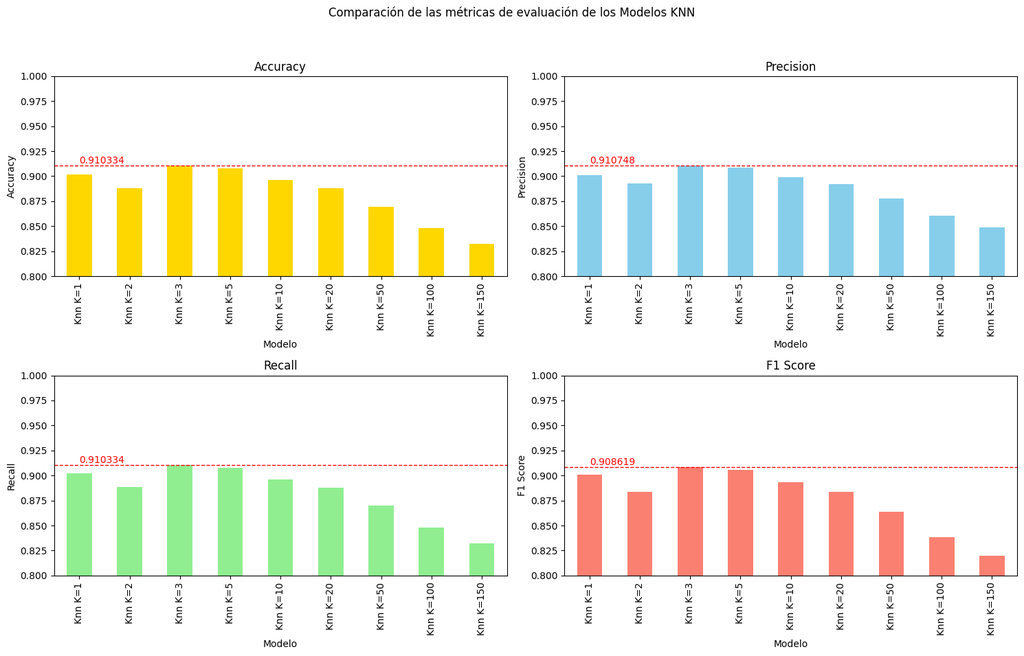

```python
import matplotlib.pyplot as plt
import numpy as np

# Creamos una figura y ejes con matplotlib
fig, axes = plt.subplots(nrows=2, ncols=2, figsize=(15, 10))
fig.suptitle('Comparación de las métricas de evaluación de los Modelos KNN')

# Definimos una función para calcular el valor máximo y añadir una línea discontinua roja
def add_max_line(ax, series, color='r'):
    max_value = series.max()
    ax.axhline(max_value, color=color, linestyle='--', linewidth=1)
    ax.text(0, max_value, f'{max_value:.6f}', color=color, va='bottom')

# Graficamos la exactitud y añadimos la línea discontinua en el máximo
df['Accuracy'].plot(ax=axes[0,0], kind='bar', color='gold')
add_max_line(axes[0,0], df['Accuracy'])
axes[0,0].set_title('Accuracy')
axes[0,0].set_ylabel('Accuracy')
axes[0,0].set_xlabel('Modelo')
axes[0,0].set_ylim(0.8, 1)

# Graficamos la precisión y añadimos la línea discontinua en el máximo
df['Precision'].plot(ax=axes[0,1], kind='bar', color='skyblue')
add_max_line(axes[0,1], df['Precision'])
axes[0,1].set_title('Precision')
axes[0,1].set_ylabel('Precision')
axes[0,1].set_xlabel('Modelo')
axes[0,1].set_ylim(0.8, 1)

# Graficamos el recall y añadimos la línea discontinua en el máximo
df['Recall'].plot(ax=axes[1,0], kind='bar', color='lightgreen')
add_max_line(axes[1,0], df['Recall'])
axes[1,0].set_title('Recall')
axes[1,0].set_ylabel('Recall')
axes[1,0].set_xlabel('Modelo')
axes[1,0].set_ylim(0.8, 1)

# Graficamos el f1-score y añadimos la línea discontinua en el máximo
df['F1'].plot(ax=axes[1,1], kind='bar', color='salmon')
add_max_line(axes[1,1], df['F1'])
axes[1,1].set_title('F1 Score')
axes[1,1].set_ylabel('F1 Score')
axes[1,1].set_xlabel('Modelo')
axes[1,1].set_ylim(0.8, 1)

# Ajustamos el layout para evitar la superposición
plt.tight_layout(rect=[0, 0.03, 1, 0.95])
plt.show()
```

## Visualizacion resultados.

A continuación se puede ver de namera visual cómo clasifica los elementos los diferentes modelos creados:

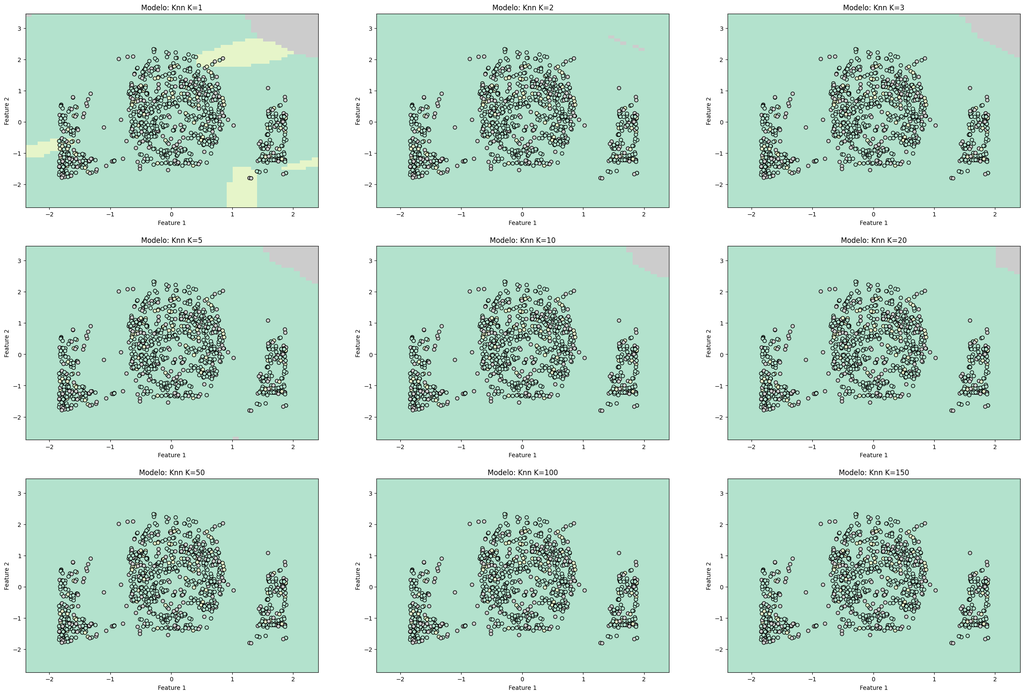

```python
import numpy as np
import warnings
warnings.filterwarnings('ignore')

# Defino la cuadrícula en función de las dos primeras características
x_min, x_max = X[:, 0].min() - .5, X[:, 0].max() + .5
y_min, y_max = X[:, 1].min() - .5, X[:, 1].max() + .5
h = .1
xx, yy = np.meshgrid(np.arange(x_min, x_max, h), np.arange(y_min, y_max, h))

# Creo una matriz ficticia con las 13 columnas del dataset y uso solamente las dos primeras (alpha y delta)
dummy_data = np.zeros((xx.ravel().shape[0], 13))
dummy_data[:, 0] = xx.ravel()
dummy_data[:, 1] = yy.ravel()

# Como el dataset proporcionado es muy amplio, reduzco el número de muestras a 1000 aleatorias.
indices = np.random.choice(range(len(X)), size=1000, replace=False)
X_subset = X[indices]
y_subset = y[indices]

plt.figure(figsize=(30, 20))
i=0
for k, v in modelos.items():
    plt.subplot(3, 3, i+1)
    Z = v.predict(dummy_data)
    Z = Z.reshape(xx.shape)
    plt.pcolormesh(xx, yy, Z, cmap=plt.cm.Pastel2)
    plt.scatter(X_subset[:, 0], X_subset[:, 1], c=y_subset, edgecolors='k', cmap=plt.cm.Pastel2)
    plt.title('Modelo: {}'.format(k))
    plt.xlabel('Feature 1')
    plt.ylabel('Feature 2')
    i +=1
plt.show()
```

Como se puede comprobar, donde mas diferencias hay es desde K=1 hasta K=20, a partir de esos valores de K las diferencias son mínimas.

## Selección del K óptimo: Número óptimo de vecinos.

Para calcular un número adecuado de vecinos, vamos a ejecutar 20 K-nn para valores de K del 1 al 20 y miraremos el error cometido para los conjuntos de datos de entrenamiento y test.

De esta manera seleccionaremos aquel valor de 'K' que tenga un cierto equilibrio entre el error cometido entre los conjuntos de datos de entrenamiento y test.

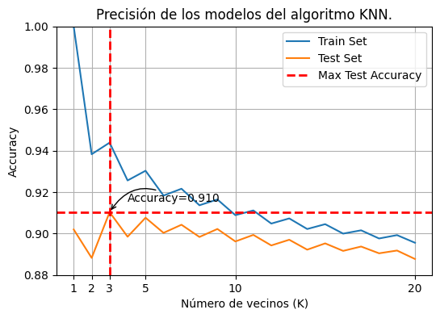

```python
from sklearn.metrics import accuracy_score
from sklearn.neighbors import KNeighborsClassifier
import matplotlib.pyplot as plt

acc_train = list()
acc_test = list()

K = 20
for k in range(1, K+1, 1):
    model = KNeighborsClassifier(n_neighbors=k)
    model.fit(X_train, y_train)
    accuracy_train = accuracy_score(y_true=y_train, y_pred=model.predict(X_train))
    accuracy_test = accuracy_score(y_true=y_test, y_pred=model.predict(X_test))
    acc_train.append(accuracy_train)
    acc_test.append(accuracy_test)

# Creo la figura y los ejes
fig, ax = plt.subplots(figsize=(6, 4))

# Dibujo los datos
ax.plot([k for k in range(1, K+1)], acc_train, label='Train Set')
ax.plot([k for k in range(1, K+1)], acc_test, label='Test Set')

# Añado título y etiquetas
ax.set_title("Precisión de los modelos del algoritmo KNN.")
ax.set_xlabel("Número de vecinos (K)")
ax.set_ylabel("Accuracy")

# Establezco los límites para el eje y
ax.set_ylim([0.88, 1])

# Establezco los ticks y etiquetas personalizadas para el eje x
ax.set_xticks([1, 2, 3, 5, 10, 20])

# Marco con línea roja discontinua el valor del accuracy para k=3
k3_accuracy = acc_test[2]
ax.axvline(x=3, color='red', linestyle='--', linewidth=2, label='Max Test Accuracy')
ax.axhline(y=k3_accuracy, color='red', linestyle='--', linewidth=2)

# Añado anotación con una flecha
ax.annotate(f'Accuracy={k3_accuracy:.3f}',
            xy=(3, k3_accuracy), xytext=(4, k3_accuracy+0.005),
            arrowprops=dict(facecolor='red', arrowstyle='->', connectionstyle='arc3,rad=.5'))

ax.grid(True)
ax.legend(loc='upper right')
plt.show()
```

Como hemos visto anteriormente y observando estos errores , podemos seleccionar como valor de K=3, ya que con este valor cometemos un error bajo con el conjunto de datos de test y tiene un error también bajo en el conjunto de datos de entrenamiento aunque este error no sea el más bajo de los datos de entrenamiento.

Gráfica de codo para ver cuál tiene menor error:

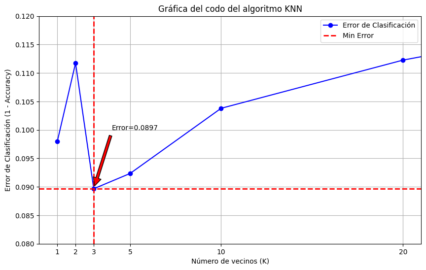

```python
import matplotlib.pyplot as plt

# Valores de k utilizados
k_values = [1, 2, 3, 5, 10, 20, 50, 100, 150]
errores = [1 - model['Accuracy'] for model in evaluacion]

# Gráfico del método del codo
plt.figure(figsize=(10, 6))
plt.plot(k_values, errores, marker='o', linestyle='-', color='blue', label='Error de Clasificación')
plt.title('Gráfica del codo del algoritmo KNN')
plt.xlabel('Número de vecinos (K)')
plt.ylabel('Error de Clasificación (1 - Accuracy)') #1 - Accuracy
plt.xticks(k_values)
plt.grid(True)

# Ajusto los límites de los ejes x e y para enfocarse en el rango deseado
plt.xlim(0, 21)
plt.ylim(0.08, 0.12)

# Dibujar una línea punteada en el codo potencial en k=3
plt.axvline(x=3, color='red', linestyle='--', linewidth=2, label='Min Error')
plt.axhline(y=errores[2], color='red', linestyle='--', linewidth=2)
plt.annotate('Error={:.4f}'.format(errores[2]), xy=(3, errores[2]), xytext=(4, 0.1),
             arrowprops=dict(facecolor='red', shrink=0.05))

plt.legend()
plt.show()
```

Como se puede observar, el valor de K más optimo es K=3, ya que registra las mejores métricas de evaluación.

Para valorar cómo de bueno es el modelo clasificación de KNN con k=3, generamos su matriz de confusion.

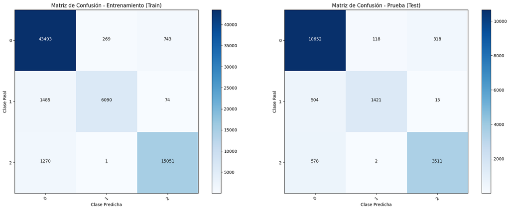

```python
import matplotlib.pyplot as plt
import numpy as np
import itertools
from sklearn.metrics import confusion_matrix

modelo = modelos['Knn K=3']

# Obtengo las predicciones del modelo sobre los conjuntos de entrenamiento y prueba
y_pred_train = modelo.predict(X_train)
y_pred_test = modelo.predict(X_test)

# Calculo las matrices de confusión
cm_train = confusion_matrix(y_true=y_train, y_pred=y_pred_train)
cm_test = confusion_matrix(y_true=y_test, y_pred=y_pred_test)

# Definimos el heatmap de la matriz de confusión usando la función existente
def plot_confusion_matrix(cm, classes, title='Matriz de Confusión', cmap=plt.cm.Blues):
    """
    Funcion que imprime y plotea la matriz de confusión.
    """
    plt.imshow(cm, interpolation='nearest', cmap=cmap)
    plt.title(title)
    plt.colorbar()
    tick_marks = np.arange(len(classes))
    plt.xticks(tick_marks, classes, rotation=45)
    plt.yticks(tick_marks, classes)

    thresh = cm.max() / 2.
    for i, j in itertools.product(range(cm.shape[0]), range(cm.shape[1])):
        plt.text(j, i, '{}'.format(cm[i, j]), horizontalalignment="center",
                 color="white" if cm[i, j] > thresh else "black")

    plt.tight_layout()
    plt.xlabel('Clase Predicha')
    plt.ylabel('Clase Real')

classes = np.unique(np.concatenate((y_train, y_test)))

# Pintamos la matriz de confusión para el conjunto de entrenamiento y prueba
plt.figure(figsize=(18, 7))
plt.subplot(1, 2, 1)
plot_confusion_matrix(cm_train, classes=classes, title='Matriz de Confusión - Entrenamiento (Train)')
plt.subplot(1, 2, 2)
plot_confusion_matrix(cm_test, classes=classes, title='Matriz de Confusión - Prueba (Test)')

plt.subplots_adjust(wspace=0)
plt.show()
```

Hago las matrices en porcentajes.

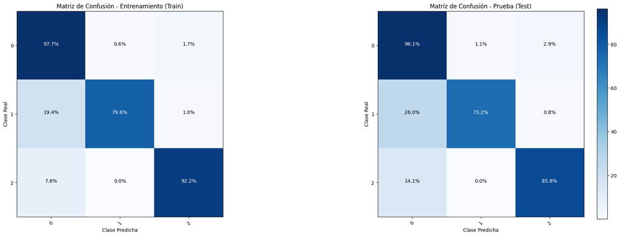

```python
import matplotlib.pyplot as plt
import numpy as np
import itertools
from sklearn.metrics import confusion_matrix

modelo = modelos['Knn K=3']

# Obtengo las predicciones del modelo sobre los conjuntos de entrenamiento y prueba
y_pred_train = modelo.predict(X_train)
y_pred_test = modelo.predict(X_test)

# Calculo las matrices de confusión
cm_train = confusion_matrix(y_true=y_train, y_pred=y_pred_train)
cm_test = confusion_matrix(y_true=y_test, y_pred=y_pred_test)

def plot_confusion_matrix_percent(cm, classes, title='Matriz de Confusión KNN', cmap=plt.cm.Blues):
    """
    Función que imprime y plotea la matriz de confusión en porcentajes.
    """
    # Normalizo la matriz de confusión para obtener porcentajes
    cm_percent = cm.astype('float') / cm.sum(axis=1)[:, np.newaxis] * 100

    plt.imshow(cm_percent, interpolation='nearest', cmap=cmap)
    plt.title(title)
    plt.colorbar()
    tick_marks = np.arange(len(classes))
    plt.xticks(tick_marks, classes, rotation=45)
    plt.yticks(tick_marks, classes)

    thresh = cm_percent.max() / 2.
    for i, j in itertools.product(range(cm_percent.shape[0]), range(cm_percent.shape[1])):
        plt.text(j, i, '{:.1f}%'.format(cm_percent[i, j]), horizontalalignment="center",
                 color="white" if cm_percent[i, j] > thresh else "black")

    plt.tight_layout()
    plt.xlabel('Clase Predicha')
    plt.ylabel('Clase Real')

classes = np.unique(np.concatenate((y_train, y_test)))

# Pintamos la matriz de confusión en porcentajes para el conjunto de entrenamiento y prueba
plt.figure(figsize=(18, 7))
plt.subplot(1, 2, 1)
plot_confusion_matrix_percent(cm_train, classes=classes, title='Matriz de Confusión - Entrenamiento (Train)')
plt.subplot(1, 2, 2)
plot_confusion_matrix_percent(cm_test, classes=classes, title='Matriz de Confusión - Prueba (Test)')

plt.subplots_adjust(wspace=0.4)
plt.show()
```

Recapitulamos y obtenemos las métricas de evaluación del modelo K=3.

```python
# Extraemos las metricas del modelo K=3
k3_metrics = df.loc['Knn K=3']
k3_metrics_df = pd.DataFrame(k3_metrics).T
k3_metrics_df
```

|  | Accuracy | Precision | Recall | F1 |
| --- | --- | --- | --- | --- |
| Knn K=3 | 0.910334 | 0.910748 | 0.910334 | 0.908619 |

Y obtenemos también el tiempo de entrenamiento del modelo K=3

```python
# Convertimos los tiempos de entrenamiento a DataFrame
df_tiempos = pd.DataFrame(list(tiempos_entrenamiento.items()), columns=['Modelo', 'Tiempo de entrenamiento (s)'])

# Selecciono el tiempo de entrenamiento para el modelo K=3
df_tiempo_k3 = df_tiempos.iloc[[2]]

# Configuramos 'Modelo' como índice
df_tiempo_k3.set_index("Modelo", inplace=True)

print("\nTiempo de entrenamiento para K=3:")
df_tiempo_k3
```

```
Tiempo de entrenamiento para K=3:
```

| Modelo | Tiempo de entrenamiento (s) |
| --- | --- |
| Knn K=3 | 0.07411 |

## Conclusiones.

Tras evaluar y comparar los diferentes modelos de clasificación de KNN con las métricas apropiadas, se puede llegar a la conclusión de que el modelo Knn K=3 es el más efectivo y adecuado para el escenario en cuestión.

El modelo Knn K=3 muestra un rendimiento sólido en todas las métricas de evaluación utilizadas.

- En primer lugar, presenta el mayor valor de accuracy, lo que indica que es capaz de clasificar correctamente aproximadamente el 91.03% de las muestras en el conjunto de prueba. Esta alta exactitud en las predicciones es un factor clave en la evaluación del modelo, ya que proporciona una medida general de su capacidad para clasificar de manera correcta y precisa.
- En cuanto a la precisión, el modelo exhibe el mayor valor entre todos los modelos evaluados. La precisión representa la proporción de predicciones positivas correctas, y en este caso, logra una alta proporción de aciertos en las predicciones positivas. Esto demuestra su habilidad para identificar correctamente las muestras positivas en el conjunto de prueba.
- También muestra el mayor recall entre los modelos evaluados. El recall es una medida importante para evaluar la capacidad de un modelo para identificar correctamente las muestras positivas. Su alto valor indica que el modelo tiene una buena capacidad para detectar y clasificar correctamente las muestras positivas en el conjunto de prueba.
- Finalmente, al considerar el F1-score, que combina la precisión y el recall, el modelo Knn K=3 obtiene un valor alto, lo que indica un buen equilibrio entre estas dos métricas. Esto demuestra que el modelo Knn K=3 es capaz de proporcionar un rendimiento sólido tanto en la precisión como en la capacidad de detección de las muestras positivas.

En resumen, basándonos en un análisis exhaustivo de las métricas de evaluación, podemos concluir que el modelo Knn K=3 es adecuado para este escenario.